# Data Visualisation project

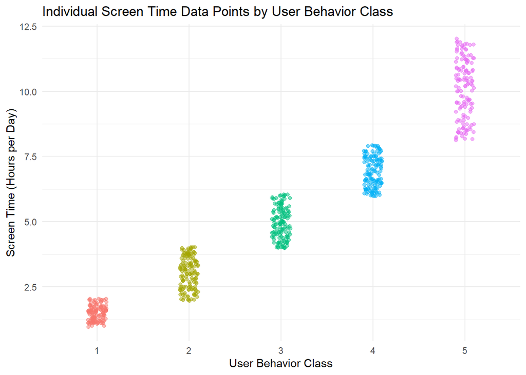

```r
# Jitter Plot of Screen Time by User Behavior Class
ggplot(data, aes(x = as.factor(User_Behavior_Class), y = Screen_Time_Hours_Per_Day, color = as.factor(User_Behavior_Class))) +
  geom_jitter(width = 0.1, alpha = 0.5) +
  labs(
    title = "Individual Screen Time Data Points by User Behavior Class",
    x = "User Behavior Class",
    y = "Screen Time (Hours per Day)"
  ) +
  theme_minimal() +
  theme(legend.position = "none")
```

#Homework 9:

#Graph 1: This graph helps analyze if battery consumption correlates with data usage and whether the pattern differs by gender within each user behavior class. High battery consumption with low data usage may indicate inefficient apps or background activity.

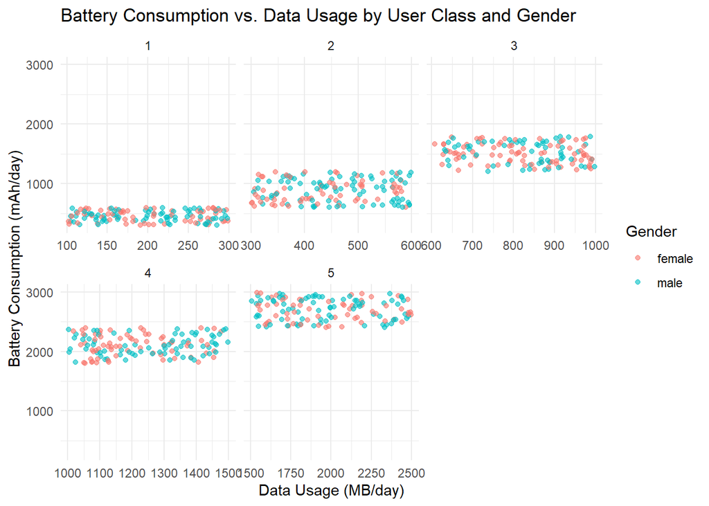

```r
ggplot(data, aes(x = Data_Usage_MB_Per_Day, y = Battery_Consumption_mAh_Per_Day, color = Gender)) +
  geom_point(alpha = 0.6) +
  facet_wrap(~ User_Behavior_Class,scales = "free_x") +
  labs(title = "Battery Consumption vs. Data Usage by User Class and Gender",
       x = "Data Usage (MB/day)",
       y = "Battery Consumption (mAh/day)",
       color = "Gender") +
  theme_minimal()
```

#Graph 2:

This graph shows the proportion of each device model within different user behavior classes. It helps identify if specific user behavior classes prefer certain devices more than others.

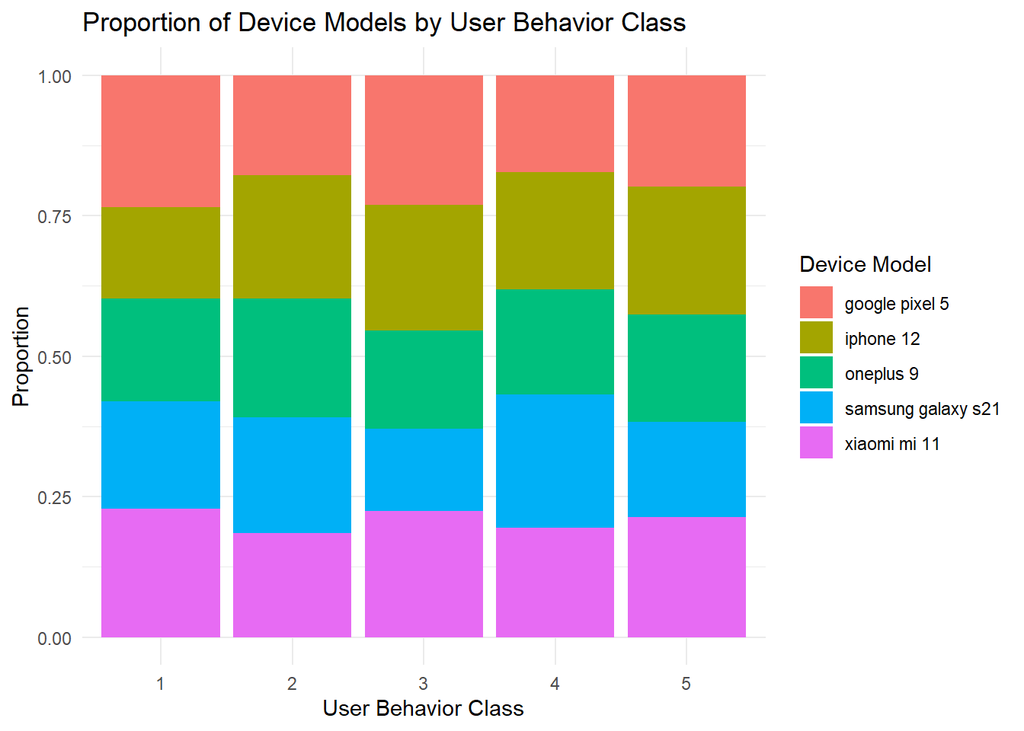

```r
ggplot(data, aes(x = as.factor(User_Behavior_Class), fill = Device_Model)) +
  geom_bar(position = "fill") +  # 'fill' shows proportions
  labs(title = "Proportion of Device Models by User Behavior Class",
       x = "User Behavior Class",
       y = "Proportion",
       fill = "Device Model") +
  theme_minimal()
```

#Graph 3 :

The violin plot will show the distribution and density of app usage time for each gender, separated by user behavior class. It helps identify if certain classes or genders spend more time using apps and how usage varies within each class..

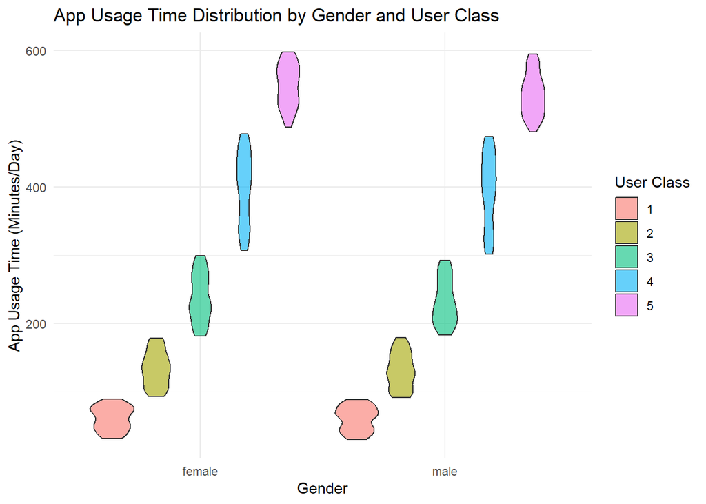

```r
ggplot(data, aes(x = Gender, y = App_Usage_Time_Mins_Per_Day, fill = as.factor(User_Behavior_Class))) +
  geom_violin(alpha = 0.6) +
  labs(title = "App Usage Time Distribution by Gender and User Class",
       x = "Gender",
       y = "App Usage Time (Minutes/Day)",
       fill = "User Class") +
  theme_minimal()
```

#Graph 4 :

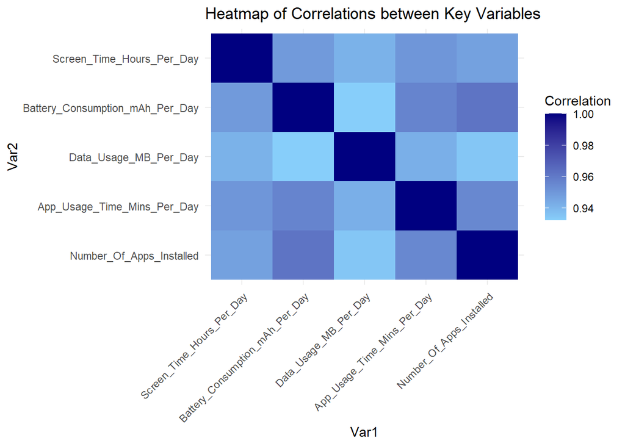

```r
library(ggplot2)
library(reshape2)

# Select numerical variables
num_vars <- data[, c("Screen_Time_Hours_Per_Day", "Battery_Consumption_mAh_Per_Day",
                     "Data_Usage_MB_Per_Day", "App_Usage_Time_Mins_Per_Day",
                     "Number_Of_Apps_Installed")]

# Calculate correlation matrix
cor_matrix <- cor(num_vars, use = "complete.obs")

# Melt for ggplot2
cor_melt <- melt(cor_matrix)

cor_melt$Var2 <- factor(cor_melt$Var2, levels = rev(colnames(cor_matrix)))


# Plot heatmap
ggplot(cor_melt, aes(Var1, Var2, fill = value)) +
  geom_tile() +
  labs(title = "Heatmap of Correlations between Key Variables", fill = "Correlation") +
  theme_minimal() +
  scale_fill_gradient(low = "lightskyblue", high = "navy") +
  theme(
    axis.text.x = element_text(angle = 45, hjust = 1),
    axis.text.y = element_text(angle = 0)
  )
```

#Graph 5 :

This visual helps identify whether certain user behavior classes favor iOS or Android more. For example, if a class heavily uses iOS, it may reflect a preference for specific usage patterns or demographics.

```r
unique(data$Operating_System)
```

```
## [1] "android" "ios"
```

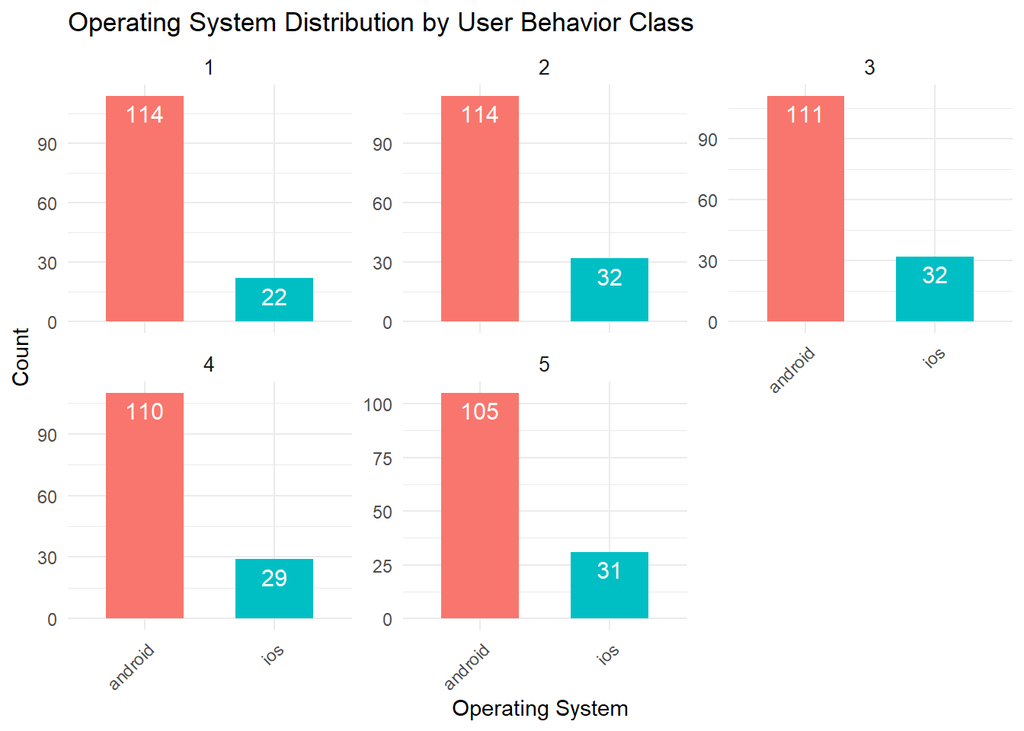

```r
library(ggplot2)
library(dplyr)

# Clean the data to ensure no NA or empty values
data_clean <- data %>%
  filter(!is.na(Operating_System) & Operating_System != "")

# Summarize data for OS distribution within each user behavior class
os_summary <- data_clean %>%
  group_by(User_Behavior_Class, Operating_System) %>%
  summarise(Count = n(), .groups = "drop")

# Plot bar graph with counts and adjusted label position
ggplot(os_summary, aes(x = Operating_System, y = Count, fill = Operating_System)) +
  geom_bar(stat = "identity", position = "dodge", width = 0.6) +
  geom_text(aes(label = Count),
            vjust = 1.5,
            size = 4,
            color = "white") +
  facet_wrap(~ User_Behavior_Class, scales = "free_y") +
  labs(title = "Operating System Distribution by User Behavior Class",
       y = "Count", x = "Operating System", fill = "Operating System") +
  theme_minimal() +
  theme(legend.position = "none",
        strip.text = element_text(size = 10),
        axis.text.x = element_text(angle = 45, hjust = 1))
```

```r
library(dplyr)

# Clean the data to ensure no NA or empty values
data_clean <- data %>%
  filter(!is.na(Operating_System) & Operating_System != "")

# Summarize data for OS distribution within each user behavior class
os_summary <- data_clean %>%
  group_by(User_Behavior_Class, Operating_System) %>%
  summarise(Count = n(), .groups = "drop")

# Calculate total count per User Behavior Class to compute percentages
os_percentage <- os_summary %>%
  group_by(User_Behavior_Class) %>%
  mutate(Total_Count = sum(Count)) %>%
  ungroup() %>%
  mutate(Percentage = (Count / Total_Count) * 100)

# Display the table with percentages
os_percentage_table <- os_percentage %>%
  select(User_Behavior_Class, Operating_System, Count, Percentage) %>%
  arrange(User_Behavior_Class, Operating_System)

# Print the table
print(os_percentage_table)
```

```
## # A tibble: 10 × 4
##    User_Behavior_Class Operating_System Count Percentage
##                  <int> <chr>            <int>      <dbl>
##  1                   1 android            114       83.8
##  2                   1 ios                 22       16.2
##  3                   2 android            114       78.1
##  4                   2 ios                 32       21.9
##  5                   3 android            111       77.6
##  6                   3 ios                 32       22.4
##  7                   4 android            110       79.1
##  8                   4 ios                 29       20.9
##  9                   5 android            105       77.2
## 10                   5 ios                 31       22.8
```

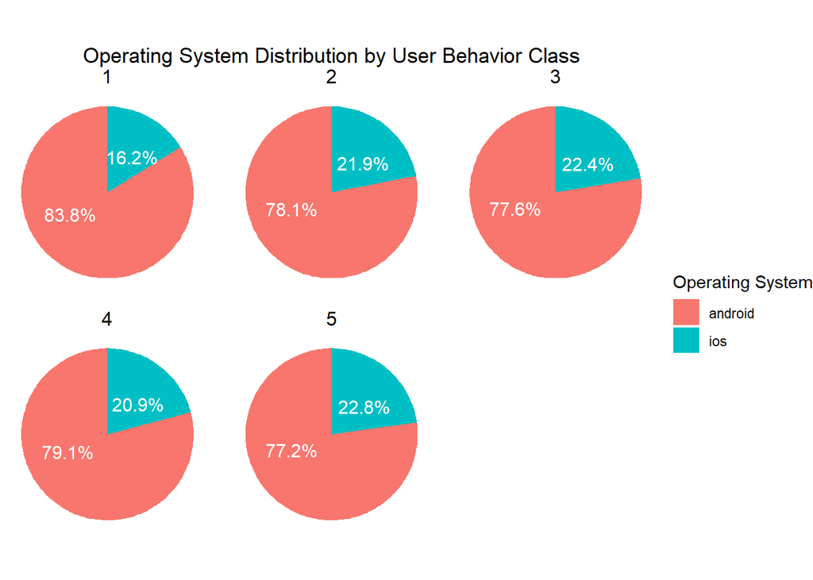

```r
library(ggplot2)

# Create a pie chart with better label placement
ggplot(os_percentage_table, aes(x = "", y = Percentage, fill = Operating_System)) +
  geom_bar(stat = "identity", width = 1) +
  coord_polar("y") +
  facet_wrap(~ User_Behavior_Class) +
  labs(title = "Operating System Distribution by User Behavior Class", fill = "Operating System") +
  theme_void() +
  theme(
    plot.title = element_text(hjust = 0.5),
    strip.text = element_text(size = 12)
  ) +
  # Adding percentage labels
  geom_text(aes(label = paste0(round(Percentage, 1), "%")),
            position = position_stack(vjust = 0.6),
            size = 4,
            color = "white")
```

```r
table(data_clean$User_Behavior_Class, data_clean$Operating_System)
```

```
##
##     android ios
##   1     114  22
##   2     114  32
##   3     111  32
##   4     110  29
##   5     105  31
```

#Graph 6 :

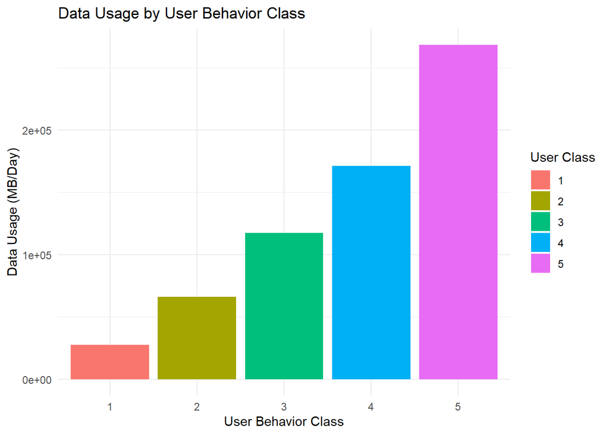

```r
ggplot(data, aes(x = factor(User_Behavior_Class), y = Data_Usage_MB_Per_Day, fill = factor(User_Behavior_Class))) +
  geom_bar(stat = "identity") +
  labs(title = "Data Usage by User Behavior Class",
       x = "User Behavior Class",
       y = "Data Usage (MB/Day)",
       fill = "User Class") +
  theme_minimal()
```

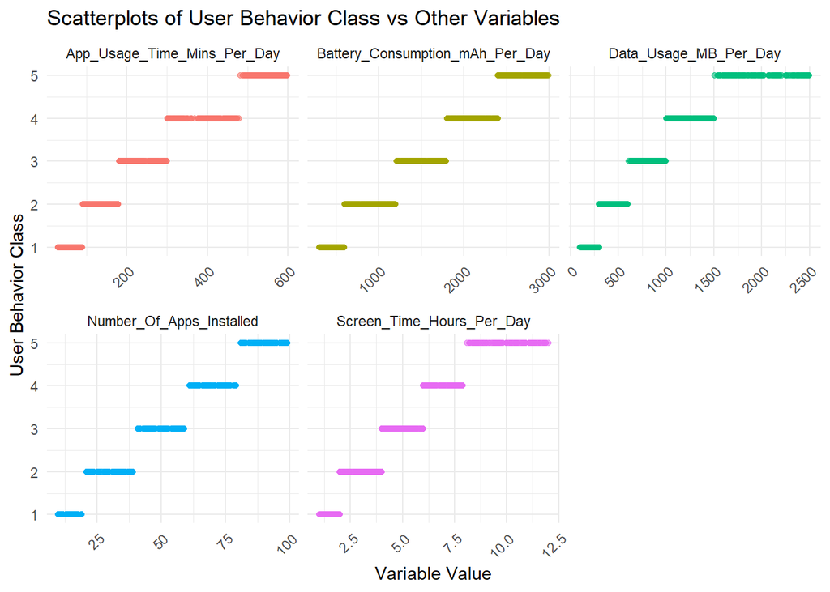

```r
library(ggplot2)
library(tidyr)

# Select relevant variables
scatter_data <- data[, c("User_Behavior_Class",
                         "Screen_Time_Hours_Per_Day",
                         "Battery_Consumption_mAh_Per_Day",
                         "Data_Usage_MB_Per_Day",
                         "App_Usage_Time_Mins_Per_Day",
                         "Number_Of_Apps_Installed")]

# Convert data to long format for faceting
scatter_long <- pivot_longer(scatter_data,
                             cols = -User_Behavior_Class,
                             names_to = "Variable",
                             values_to = "Value")

# Plot scatterplots with faceting
ggplot(scatter_long, aes(x = Value, y = User_Behavior_Class, color = Variable)) +
  geom_point(alpha = 0.6) +
  facet_wrap(~ Variable, scales = "free_x") +
  labs(title = "Scatterplots of User Behavior Class vs Other Variables",
       x = "Variable Value",
       y = "User Behavior Class") +
  theme_minimal() +
  theme(legend.position = "none",
        axis.text.x = element_text(angle = 45, vjust = 1, hjust = 1))
```